# GLMM Model Demo: Sleep Study

Chris Troeger

January 3, 2022

# This script is intended to demonstrate how to use and interpret a generalized linear mixed model (GLMM) in R

Linear mixed models are models that incorporate grouping, clustering, or repeated measurements from a dataset into a statistical regression model. I will try to consistently use the term *hierarchical* to describe data that were generated in this way. *Generalized* is a way to extend linear models to transformed outcomes (log, logit, Poisson, etc). Other names for this model structure are:

- Hierarchical models
- Mixed-effects models
- Random-effects models (random intercepts; random slopes)
- Multi-level models

There are two main packages to run linear mixed models in R.

- $lme4$
- $nlme$

I prefer using lme4 so that is what I will use in this script. I am also using

- $ggplot2$ (graphing)
- $data.table$ (my prefered environment for data management)

The data we will use is in the **lme4** package. These data are called “sleepstudy” and represent 18 individuals in a sleep deprivation study where reaction time is measured per day of deprivation. You can learn more about it by typing $help(sleepstudy)$ in your R console (after $library(lme4)$).

## Load packages and data

```r
##########################################
## Simple demonstration of generalized linear
## mixed models
##########################################
library(data.table)
library(lme4)
library(nlme)
library(ggplot2)

## Use "sleepstudy" to illustrate
# ?sleepstudy : # Reaction times in a sleep deprivation study

dt <- data.table(sleepstudy)
```

## Data investigation

Let’s investigate the dataset and get a sense of it. How did I know there are 18 Subjects in the study?

```r
dt
```

```
##      Reaction Days Subject
##   1: 249.5600    0     308
##   2: 258.7047    1     308
##   3: 250.8006    2     308
##   4: 321.4398    3     308
##   5: 356.8519    4     308
##  ---
## 176: 329.6076    5     372
## 177: 334.4818    6     372
## 178: 343.2199    7     372
## 179: 369.1417    8     372
## 180: 364.1236    9     372
```

```r
summary(dt)
```

```
##     Reaction          Days        Subject
##  Min.   :194.3   Min.   :0.0   308    : 10
##  1st Qu.:255.4   1st Qu.:2.0   309    : 10
##  Median :288.7   Median :4.5   310    : 10
##  Mean   :298.5   Mean   :4.5   330    : 10
##  3rd Qu.:336.8   3rd Qu.:7.0   331    : 10
##  Max.   :466.4   Max.   :9.0   332    : 10
##                                (Other):120
```

One of the first things to do with a dataset is to plot it.

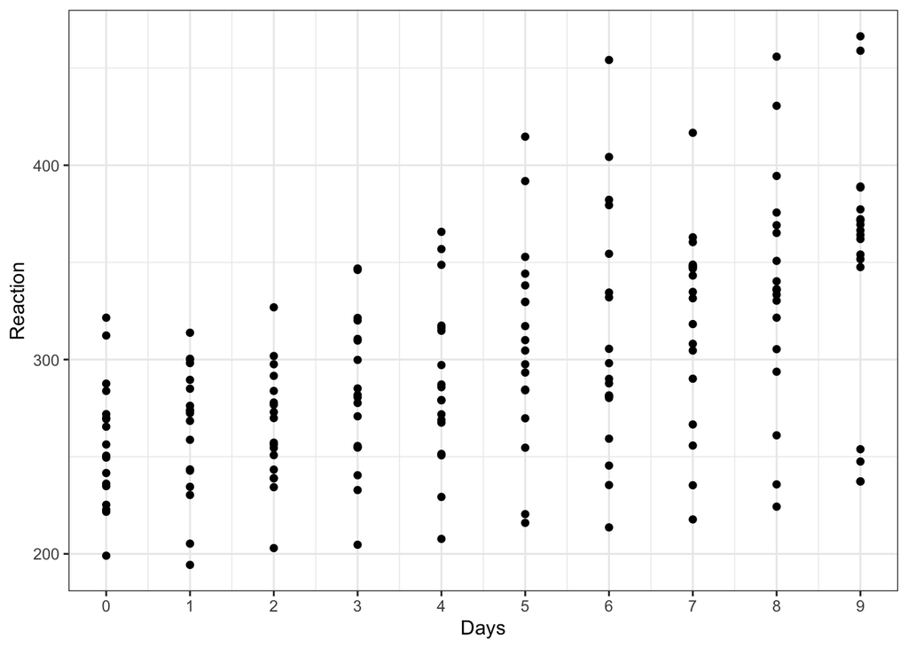

```r
ggplot(dt, aes(x = Days, y = Reaction)) + geom_point() + theme_bw() +
  scale_x_continuous(breaks = 0:9)
```

## Linear Model

So it seems that with each day of sleep deprivation, reaction time increases. Let’s quantify by how much using a simple linear model (ordinary least squares; OLS). How do we interpret the results of the model?

```r
# This should look familiar, it is how we specify a linear regression
# where Reaction is the outcome and Days the predictor
my_lm <- lm(Reaction ~ Days, data = dt)
summary(my_lm) # Reaction time increases by ~10.5 milliseconds per day
```

```
##
## Call:
## lm(formula = Reaction ~ Days, data = dt)
##
## Residuals:
##      Min       1Q   Median       3Q      Max
## -110.848  -27.483    1.546   26.142  139.953
##
## Coefficients:
##             Estimate Std. Error t value Pr(>|t|)
## (Intercept)  251.405      6.610  38.033  < 2e-16 ***
## Days          10.467      1.238   8.454 9.89e-15 ***
## ---
## Signif. codes:  0 '***' 0.001 '**' 0.01 '*' 0.05 '.' 0.1 ' ' 1
##
## Residual standard error: 47.71 on 178 degrees of freedom
## Multiple R-squared:  0.2865, Adjusted R-squared:  0.2825
## F-statistic: 71.46 on 1 and 178 DF,  p-value: 9.894e-15
```

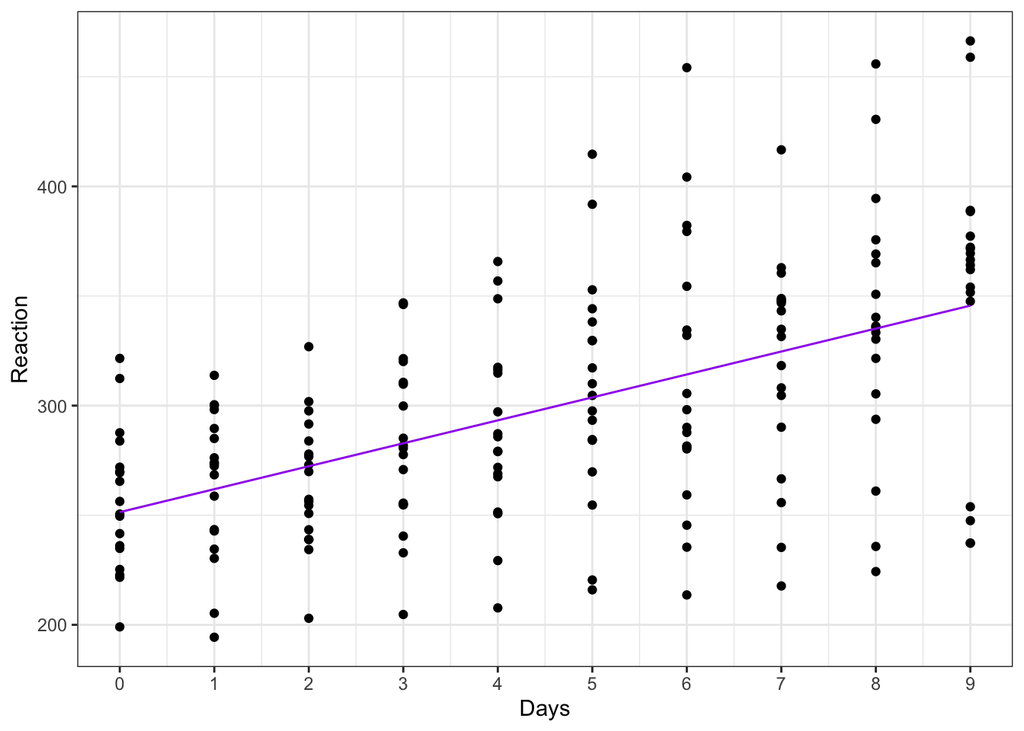

```r
# The predict function produces regression fit estimates for each
# row in the original dataset
dt$linear_pred <- predict(my_lm)

ggplot(dt, aes(x = Days, y = Reaction)) + geom_point() + theme_bw() +
  scale_x_continuous(breaks = 0:9) +
  geom_line(aes(y = linear_pred), col = "purple")
```

## Illustration of hierarchical data

From our knowledge of these data, we know that they are not independent. This is because each Subject contributes 10 days of reaction time data. We would expect that some people have some unmeasured characteristic that makes them faster or slower at reacting at baseline. Let’s plot this in a few ways.

**First, let’s see the distribution of reaction times within and between individuals**

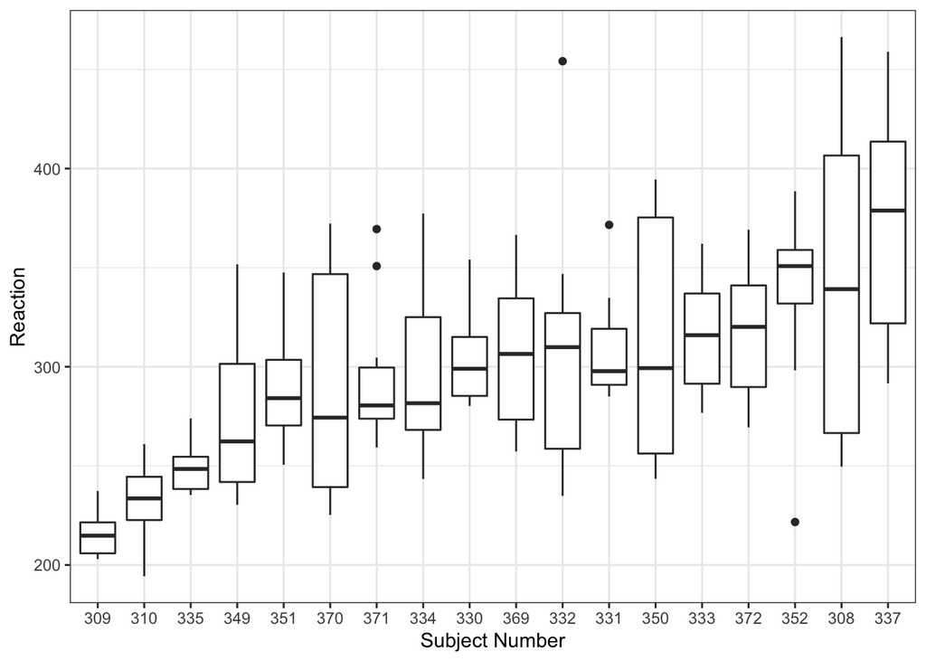

```r
# the random intercept reflects variation by individual
# These pieces of code are simply to plot the
# subjects by increasing order of mean reaction time
dt[, subject_order := factor(Subject)]
dt[, subject_order := reorder(subject_order, Reaction, mean)]

ggplot(dt, aes(x = subject_order, y = Reaction)) + geom_boxplot() + theme_bw() +
  xlab("Subject Number")
```

Subject 309 consistently has the fastest reaction times while Subject 337 the slowest.

**Now, let’s make the same scatterplot but with lines showing the trends for each Subject**

We can see that at Day 0 (intercept), there is a range from 200 to about 325 between Subjects. There also seems to be a general increasing trend, but some Subjects have different slopes.

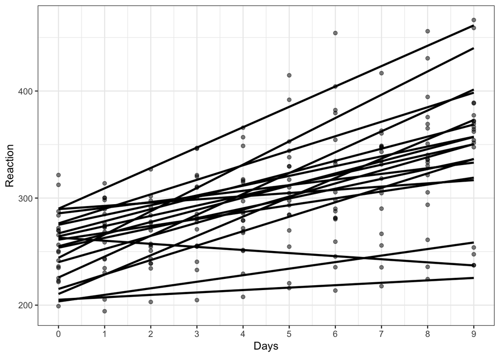

```r
# Let's replot, considering individuals
ggplot(dt, aes(x = Days, y = Reaction)) + geom_point(alpha = 0.5) + theme_bw() +
  scale_x_continuous(breaks = 0:9) +
  stat_smooth(aes(group = Subject), method = "lm", # stat_smooth is a quick way to plot linear fit
                       se = F, col = "black")
```

**Lastly, let’s plot our linear (OLS) prediction, separate by Subject**

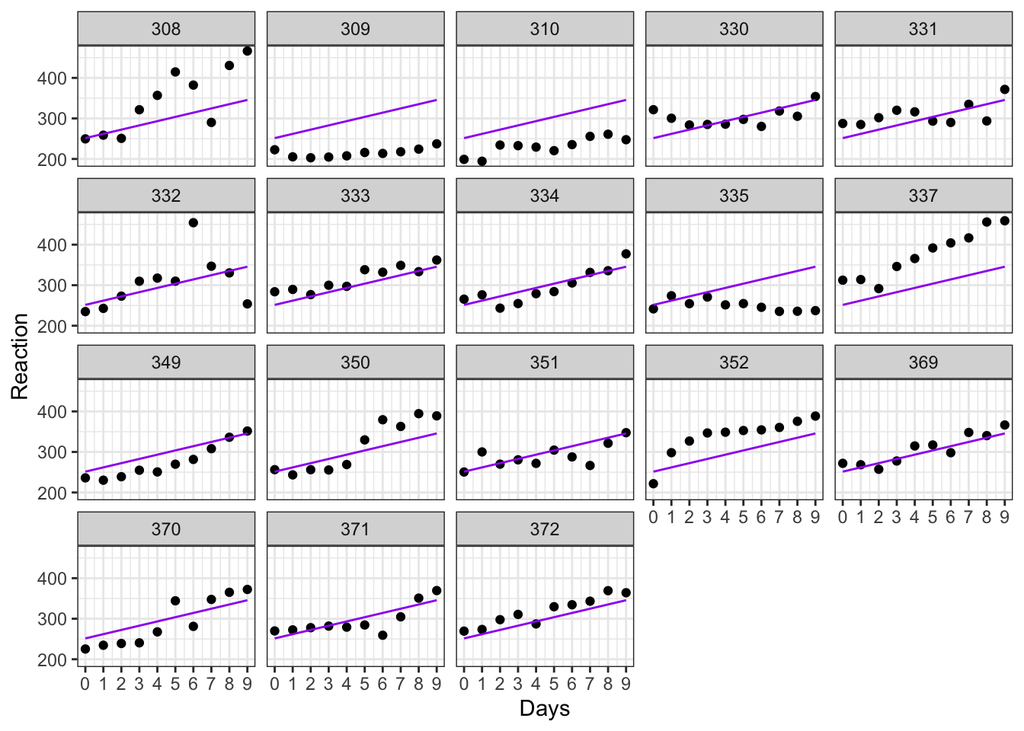

```r
# Add a panel
ggplot(dt, aes(x = Days, y = Reaction)) + geom_point() + theme_bw() +
  scale_x_continuous(breaks = 0:9) +
  geom_line(aes(y = linear_pred), col = "purple") +
  facet_wrap(~Subject) # This will create a panel for Subjects
```

Our model isn’t too bad for most Subjects, but there is variation in its fit by individual. Let’s see if we can improve it (and our uncertainty) by considering the data structure.

## Now, we will run our linear mixed model

The key idea of a mixed model is that the data are grouped or structured in some way (hierarchical). Take these data for example, there are multiple observations for each Subject. To correctly account for this variation in the estimates of our effect sizes and standard errors, we should include this information in the model. Often, these models are written

$$y_i \sim \beta_0 + \alpha_{0,j} + \beta_1Days_i + \epsilon_i$$
Where $\beta_0$ is the overall intercept, $\beta_1$ is the coefficient for the slope in reaction time for $Day_i$, $\epsilon_i$ is the error term, and $\alpha_{0,j}$ is the random intercept (Day 0) for Subject $j$.

The random intercept is normally distributed with mean 0 and variance $\sigma^2_{\alpha}$

$$\alpha_j \sim N(0, \sigma^2_{\alpha})$$

We will cover this in more detail in the lecture, but for now let’s see how to implement it in R.

**This model is a random intercept model. We will allow the value of Reaction $y_i$ to vary by Subject $j$ when Days = 0.**

In the lme4 package, we will use the function $lmer$ to run a mixed model. We specify random intercepts like this:

```r
# lmer functions the same as lm. The difference is that we
# *must* specify a random effect, the (1 | X) part of the code
my_lmer <- lmer(Reaction ~ Days + (1 | Subject), data = dt)
#my_lmer <- lmer(Reaction ~ Days, data = dt) # Not run, will produce an error
summary(my_lmer)
```

```
## Linear mixed model fit by REML ['lmerMod']
## Formula: Reaction ~ Days + (1 | Subject)
##    Data: dt
##
## REML criterion at convergence: 1786.5
##
## Scaled residuals:
##     Min      1Q  Median      3Q     Max
## -3.2257 -0.5529  0.0109  0.5188  4.2506
##
## Random effects:
##  Groups   Name        Variance Std.Dev.
##  Subject  (Intercept) 1378.2   37.12
##  Residual              960.5   30.99
## Number of obs: 180, groups:  Subject, 18
##
## Fixed effects:
##             Estimate Std. Error t value
## (Intercept) 251.4051     9.7467   25.79
## Days         10.4673     0.8042   13.02
##
## Correlation of Fixed Effects:
##      (Intr)
## Days -0.371
```

Now we will plot those predictions, compared against the simple OLS model.

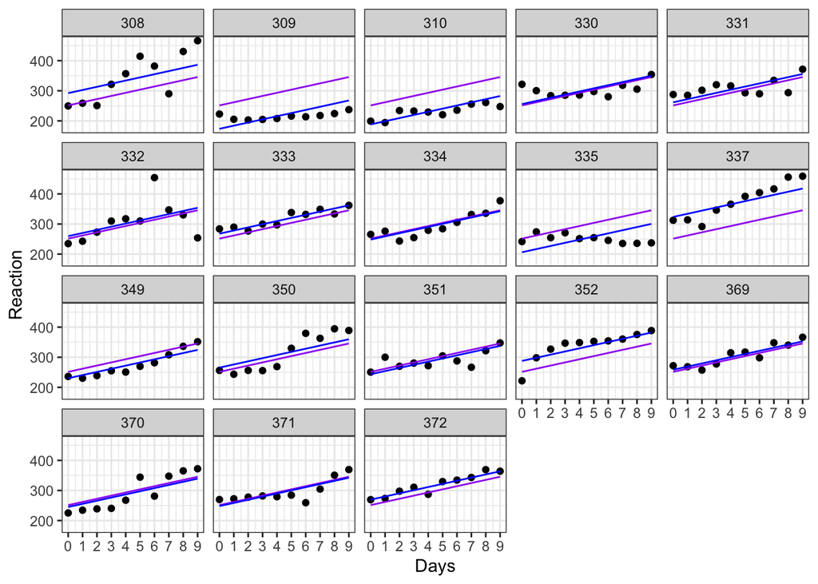

```r
# Predict from a "merMod" (the object created by lmer) works
# exactly the same as for predict.lm
dt$ran_int_pred <- predict(my_lmer)

ggplot(dt, aes(x = Days, y = Reaction)) + geom_point() + theme_bw() +
  scale_x_continuous(breaks = 0:9) + facet_wrap(~Subject) +
  geom_line(aes(y = linear_pred), col = "purple") +
  geom_line(aes(y = ran_int_pred), col = "blue")
```

I am plotting just four Subjects below so we can more easily see that the slopes are parallel but each Subject now has a different value of Reaction when Days = 0.

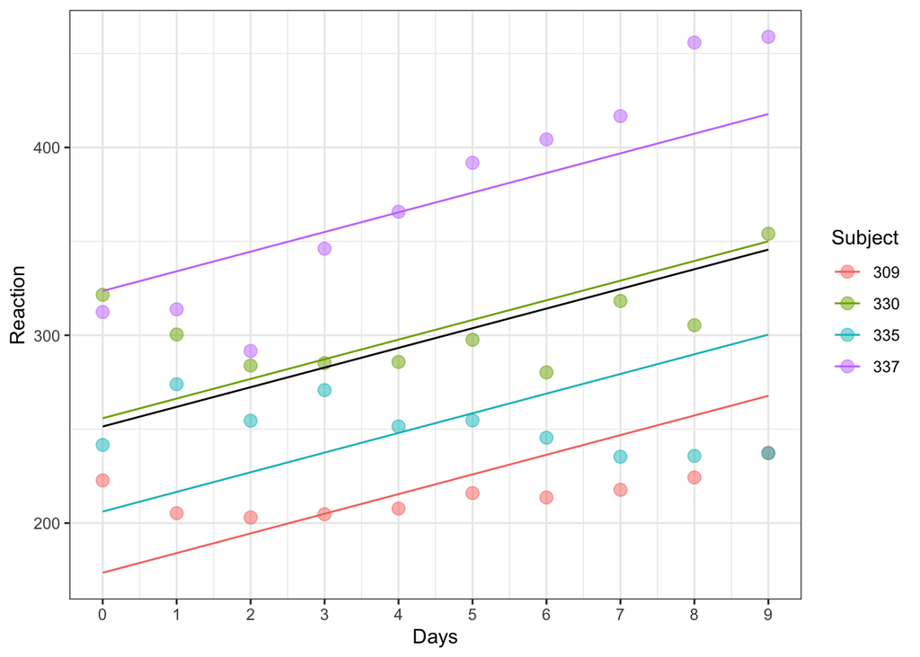

```r
my_subjects <- c(309, 335, 337, 330)
ggplot(dt[Subject %in% my_subjects], aes(x = Days, y = Reaction)) +
  geom_point(aes(col = Subject), size = 3, alpha = 0.5) + theme_bw() +
  scale_x_continuous(breaks = 0:9) +
  geom_line(aes(y = linear_pred), col = "black") +
  geom_line(aes(y = ran_int_pred, col = Subject))
```

Another common task is to extract the coefficients from this model. Here is how we extract and plot the random intercepts.

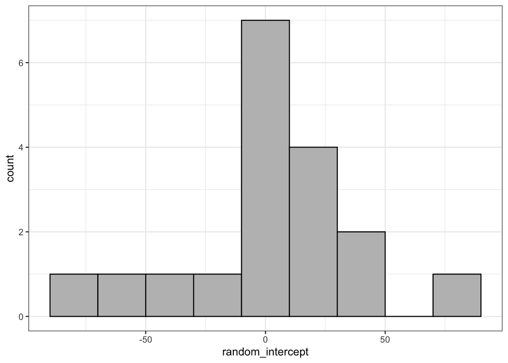

```r
fix_ef <- fixef(my_lmer) # Fixed-effects (grand Intercept and Days)
ran_ef <- ranef(my_lmer) # Is a list object
# Let's convert that into a data table instead of a list
ran_ef <- as.data.table(ran_ef) # Also works with as.data.frame()

# This has column names that are non-intuitive to me
# condval is the conditional value (difference from overall intercept)
# condsd is the conditional standard deviation (why is it the same for all Subjects?)
setnames(ran_ef, c("grp","condval"),
         c("Subject","random_intercept"))

# Plot the values of the random intercepts (should be centered at 0)
ggplot(ran_ef, aes(x = random_intercept)) +
  geom_histogram(binwidth = 20, fill = "gray", col = "black") +
  theme_bw()
```

```r
# Not exactly, but the mean should be 0
mean(ran_ef$random_intercept)
```

```
## [1] 4.168276e-13
```

Remember that the actual intercept for each Subject is the overall intercept shifted by the Subject’s random intercept value.

```r
ran_ef$fixed_intercept <- fix_ef[1]
ran_ef[, subject_intercept := fixed_intercept + random_intercept]
```

The other package for generalized linear mixed models that is commonly used, $nlme$ has some nice features that may be useful later in the class. For now though, let’s just see how to run a model with that package.

```r
# Syntax is slightly different, specify random effects outside of the formula, still use a |
my_nlme <- lme(Reaction ~ Days, random = ~ 1 | Subject, data = dt)
summary(my_nlme)
```

```
## Linear mixed-effects model fit by REML
##   Data: dt
##        AIC      BIC    logLik
##   1794.465 1807.192 -893.2325
##
## Random effects:
##  Formula: ~1 | Subject
##         (Intercept) Residual
## StdDev:    37.12383 30.99123
##
## Fixed effects:  Reaction ~ Days
##                 Value Std.Error  DF  t-value p-value
## (Intercept) 251.40510  9.746716 161 25.79383       0
## Days         10.46729  0.804221 161 13.01543       0
##  Correlation:
##      (Intr)
## Days -0.371
##
## Standardized Within-Group Residuals:
##        Min         Q1        Med         Q3        Max
## -3.2256707 -0.5528788  0.0108521  0.5187971  4.2506162
##
## Number of Observations: 180
## Number of Groups: 18
```

**We can also allow the model to estimate a different slope by Subject. This model is structured like**

$$y_i \sim \beta_0 + \alpha_{0,j} + \beta_1Days_i + \gamma_{1,j}Days_i + \epsilon_i$$

**where $\gamma_{1,j}$ is the slope on Days for Subject $j$.**

This is outside the scope of this demonstration, but recall that the random intercepts and random slopes are multivariate normally distributed:

$$\begin{aligned} \\
\begin{pmatrix}
\alpha_{0,j} \\
\gamma_{1,j}
\end{pmatrix} \stackrel{iid}{\sim} N \left[ \begin{pmatrix}
0 \\
0
\end{pmatrix},
\begin{pmatrix}
\sigma^2_{\alpha_0} & \rho \sigma_{\alpha_0} \sigma_{\gamma_1}\\
\rho \sigma_{\alpha_0} \sigma_{\gamma_1} & \sigma^2_{\gamma_1}
\end{pmatrix} \right] \\
\end{aligned}$$

```r
# Adding a random slope is done by specifying a variable on the
# left side of the | shape. This means the model will produce
# an estimated slope for each Subject
my_rslope <- lmer(Reaction ~ Days + (Days | Subject), data = dt)
summary(my_rslope)
```

```
## Linear mixed model fit by REML ['lmerMod']
## Formula: Reaction ~ Days + (Days | Subject)
##    Data: dt
##
## REML criterion at convergence: 1743.6
##
## Scaled residuals:
##     Min      1Q  Median      3Q     Max
## -3.9536 -0.4634  0.0231  0.4634  5.1793
##
## Random effects:
##  Groups   Name        Variance Std.Dev. Corr
##  Subject  (Intercept) 612.10   24.741
##           Days         35.07    5.922   0.07
##  Residual             654.94   25.592
## Number of obs: 180, groups:  Subject, 18
##
## Fixed effects:
##             Estimate Std. Error t value
## (Intercept)  251.405      6.825  36.838
## Days          10.467      1.546   6.771
##
## Correlation of Fixed Effects:
##      (Intr)
## Days -0.138
```

```r
# And in nlme package:
# my_lme_slope <- lme(Reaction ~ Days, random = ~ Days | Subject, data = dt)
```

Finally we will plot our predictions.

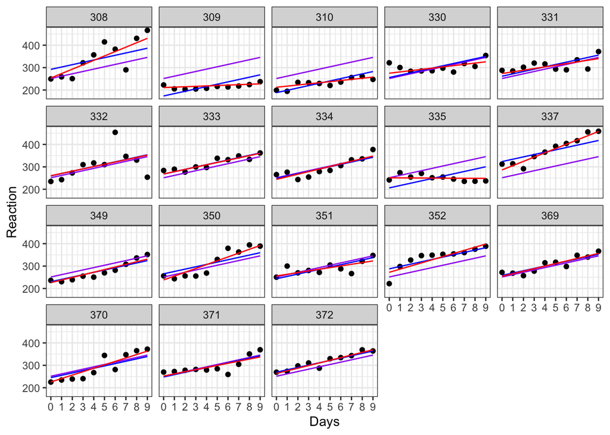

```r
dt$ran_ef_pred <- predict(my_rslope)

ggplot(dt, aes(x = Days, y = Reaction)) + geom_point() + theme_bw() +
  scale_x_continuous(breaks = 0:9) + facet_wrap(~Subject) +
  geom_line(aes(y = linear_pred), col = "purple") +
  geom_line(aes(y = ran_int_pred), col = "blue") +
  geom_line(aes(y = ran_ef_pred), col = "red")
```

Once again, let’s look at the four Subjects on the same plot so we can more clearly see that now both the slopes and the intercepts are different and that the model fit is much better (has less residual error) for each Subject.

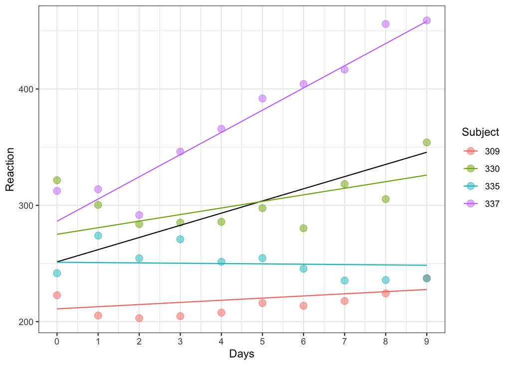

```r
ggplot(dt[Subject %in% my_subjects], aes(x = Days, y = Reaction)) +
  geom_point(aes(col = Subject), size = 3, alpha = 0.5) + theme_bw() +
  scale_x_continuous(breaks = 0:9) +
  geom_line(aes(y = linear_pred), col = "black") +
  geom_line(aes(y = ran_ef_pred, col = Subject))
```

## Model comparisons

How do we know which model is “best”? What are some of the model outputs compared to each other?

```r
# These are functions to produce estimates of model fit
# You should be familiar with AIC and BIC, but essentially
# they are penalized goodness of fit statistics. Lower
# values indicate better fits.

AIC(my_lm, my_lmer, my_rslope)
```

```
##           df      AIC
## my_lm      3 1906.293
## my_lmer    4 1794.465
## my_rslope  6 1755.628
```

```r
BIC(my_lm, my_lmer, my_rslope)
```

```
##           df      BIC
## my_lm      3 1915.872
## my_lmer    4 1807.237
## my_rslope  6 1774.786
```

It seems that including random effects does not change the parameter estimates for the Intercept or for the Days coefficients. This suggests that accounting for the hierarchical structure doesn’t change our interpretation of how sleep deprivation affects reaction time. Perhaps this is a little surprising. Also importantly, the standard error for each coefficient changes when including random intercepts and random slopes. Further, the AIC and BIC is lower for the random effects models. Based on this, my conclusion is that a model with random slopes and intercepts for each Subject produces the most reliable estimate of sleep deprivation on reaction times.